# *What If…?* | Women in Early Science Fiction

Group Members: Amola Mehta, Devin Gupta, Nishtha Das, Siddhant Bakshi

Date: 15/10/2021

### Introduction and Research Question:

Historically, women in science fiction were grossly underrepresented and were unlikely to feature as strong female leads. Instead, they were often reduced to feeble and passive roles constrained by gender norms. The idea of a female character positively contributing to science would not align with the conventionally accepted notion of women’s capabilities being distinct, and lesser than those of men. But *what if* the female characters in science fiction weren’t as uninvolved as we thought? This drew us to examine the possibility of women being written about as contributors or even distractions to scientific discovery and technological innovation. We chose two pioneers of the sci-fi genre, H.G Wells and Jules Verne to frame our historical context. Hence, our research question is: How do canonical sci-fi authors, H.G. Wells and Jules Verne, portray the dynamic between women and science/technology in their novels? With this research, we’re attempting to overturn the idea that female characters in sci-fi novels were insignificant to the plot.

### Research Hypothesis:

Based on the normative binary of women being irrational and science/technology requiring rationality, we hypothesise that women are largely depicted as obstructions or distractions from science/technology in both Wells and Verne’s works.

### Corpus Description:

The corpora we selected contains novels written by British author H.G Wells and French author Jules Verne. Our main reason for choosing this corpus was our interest in sci-novels and how they feature female protagonists. Therefore, we were curious about the relationship between women and their supposed incompatibility with science. As these two authors pioneered the sci-fi genre in the early 19-20th century, we selected them to test out our hypothesis. We have curated our corpus to include only the most popular works by both authors available on Project Gutenberg. Both corpora also happen to be approximately 1.5 million words each after clearing for metadata, making it easier to draw comparisons and inferences from the two.

### Summary Paragraph:

Our H.G Wells corpus has 18 documents with 1,556,517 total words and 39,350 unique words. His longest work is *The New Machiavelli* (1911) and his shortest is *The Time Machine* (1895). We noticed a trend in Wells’ corpus where over time the document length seems to increase. *The Time Machine* has the highest vocabulary density and *Mr Britling Sees It Through* (1916) has the lowest. We see a reverse trend in vocabulary density as it seems to be decreasing on average as we move further along his corpus. However, this isn’t surprising considering that his works became longer over the years.

Our Jules Verne corpus has 16 documents with 1,542,118 total words and 31,913 unique words. His longest work is *The Mysterious Island* (1875) and his shortest is *The Master of the World* (1904). The trend in his works is that they increase in length initially and peak with *The Mysterious Island*, followed by a steady decrease towards the latter end of his corpus. The vocabulary density in his works fluctuates but peaks in *The Underground City* (1877).

In both corpora, we also see that their canonical pieces, *The Time Machine* by Wells and *All Around the World in Eighty Days* by Verne have higher if not the highest vocabulary density as compared to the rest of their works. Based on one of the various ways in which canonicity can be understood, using simple and already common words would be one way to make writing more accessible. Therefore, it came as a mild surprise that of their works, their most popular novels seemed to work counter to this logic.

### Data Visualization 1 - Sentiment Analysis:

Sentiment analysis was a clear-cut pick for us because we wanted to gauge how Wells and Verne were writing about female entities in their novels. So, we created a cluster of 42 words that would suggest the presence of women. This included familial (“wife”, “mother”, “daughter”) and romantic (“girlfriend”, “lover”, “partner”) relations. We extended the latter to terms like “amorous”, “desire”, “sexual” etc. An assumption we made here was that romantic relationships in 19th-century novels would cater to heteronormative standards. Keeping in mind the historical context of the authors, we included terms like “maiden”, “madame” and “lady”. To account for different roles played by women in their novels, we included words such as “maid” and “governess” as well. After unnesting and cleaning the corpus, we matched it with our women cluster and Bing sentiment lexicon. This lexicon was chosen because all sentiments needed to be categorised into strictly positive (contributions) or negative (disturbances).

To execute sentiment analysis in a way that kept a focus on the context of our hypothesis, we segmented the novels in our corpus into sentences. This would help us retain the specific sentence in which a word from our cluster appeared so we could distinguish between its multiple occurrences within the same novel. However, we noticed that not all terms from our cluster had a sentiment assigned to them, at least not in the Bing lexicon. For example, the term ‘women’ had nothing attached to it. Hence, we decided to calculate the net sentiment of each term based on its sentence context. This would also provide a more informed estimation of the way the term was being used. **Graph 1.1** below demonstrates our results.

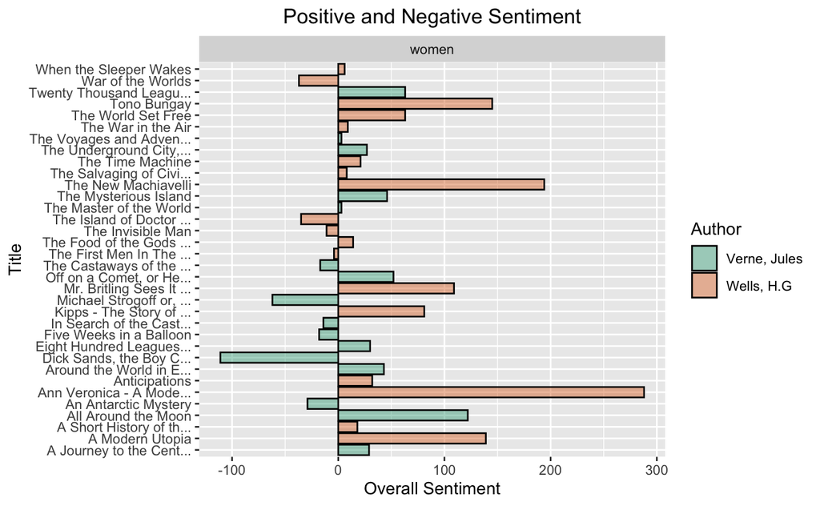

**Graph 1.1**

Here we didn’t account for the length of each novel because we didn’t expect it to have a significant impact on the net sentiment of our cluster. An author could write a long novel and therefore it could affect the number of times words from our cluster appear in it, however, this has little to no bearing on whether the sentiment will be positive or negative. Similarly, a shorter novel with consequently fewer mentions of our cluster may exist, but the length will not lead us towards a conclusive understanding of its overall sentiment. This graph illustrated the net sentiment surrounding women in each of Wells and Verne’s novels with values dipping as low as -100 but also reaching as high as almost 300. To better highlight the progression across this range of -100 to 300, we sorted the results by increasing overall sentiment, as seen in **Graph 1.2** below.

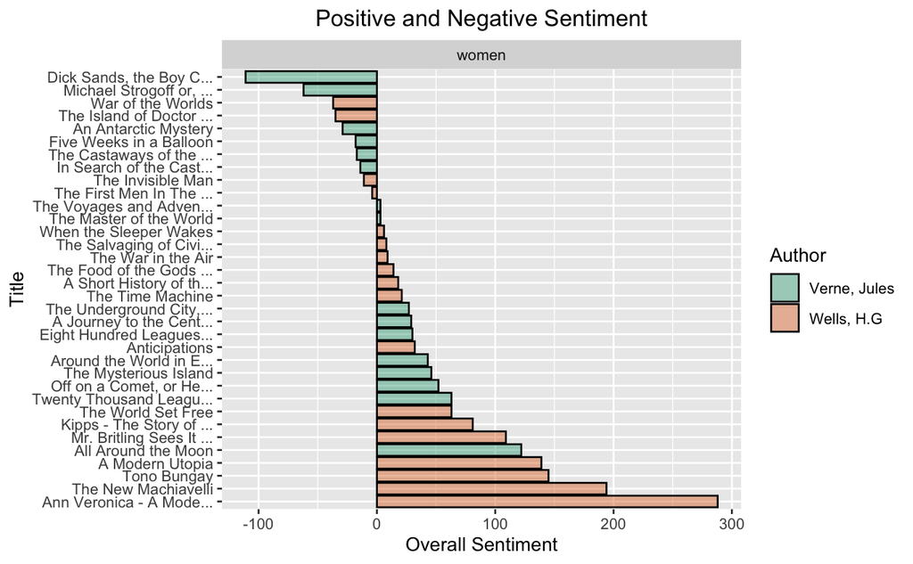

**Graph 1.2**

Now it’s much easier to point out that the novel with the most negative women sentiment is by Verne while the novel with the most positive women sentiment is by Wells. It might also be worthwhile to note how the titles of both novels are gender-specific: *Dick Sands, the Boy Captain* and *Ann Veronica - A Modern Love Story*, where the former is male-centric and the latter female-centric. Taking a quick look at their synopses, it becomes abundantly clear why women sentiments are overwhelmingly positive in *Ann Veronica*. The central plot features a young lady who rebels against her father and his patriarchal rule. However, the case with *Dick Sands, the Boy Captain* is less intuitive. This novel is described as an epic of the slave trade in Africa and offers geographical information alongside discourse about racial prejudice. Why would attitudes surrounding women be so low in this narrative? We think that in a story about the horrors of slavery and discrimination, the subsequent vocabulary/characterisation must be proportionally grim. This would mean a higher number of negative sentiment words than positive sentiment words (in terms of the Bing lexicon) and since we calculated net sentiment through sentence contexts, this could have contributed to the result.

For our hypothesis, a crucial statistic here is the ratio of texts with negative sentiments to those with positive sentiments. Out of a total of 34 texts, only 29.4% skews towards negative. This directly contradicts what we thought would happen. A hefty 70.6% of the corpus speaks of women in a charitable light. This could mean that women were contributing more than they were detracting from science within the universe of our corpus. Another important point is the lack of texts with a neutral (near 0) sentiment level. If we cap off neutrality at a net sentiment of 5 or -5, only 8.8% of the corpus satisfies this. Referring back to the belief that women would occupy passive or inconsequential roles in science fiction, this data suggests otherwise. Even if we increased the neutral sentiment range to between -15 and 15, there would still be a larger proportion of texts that suggest a non-neutral sentiment. Yet, we can’t make conclusive remarks just from this analysis because it gives us a general impression of women in the novels, which is not necessarily embedded in the context of technology. At first, we thought that it would be enough to look at this expansive data because Wells and Verne are science fiction authors and pioneers of the genre. However, not all novels from our chosen corpus can be categorised as science fiction. Even if snippets of scientific and technological information are present in the novel we’re extracting sentiment from, it cannot be enough to draw a definitive link between women and science.

### Data Visualization 2 - Sentiment Analysis with co-occurrences:

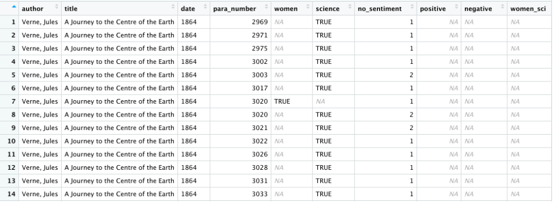

**Table 2.1**

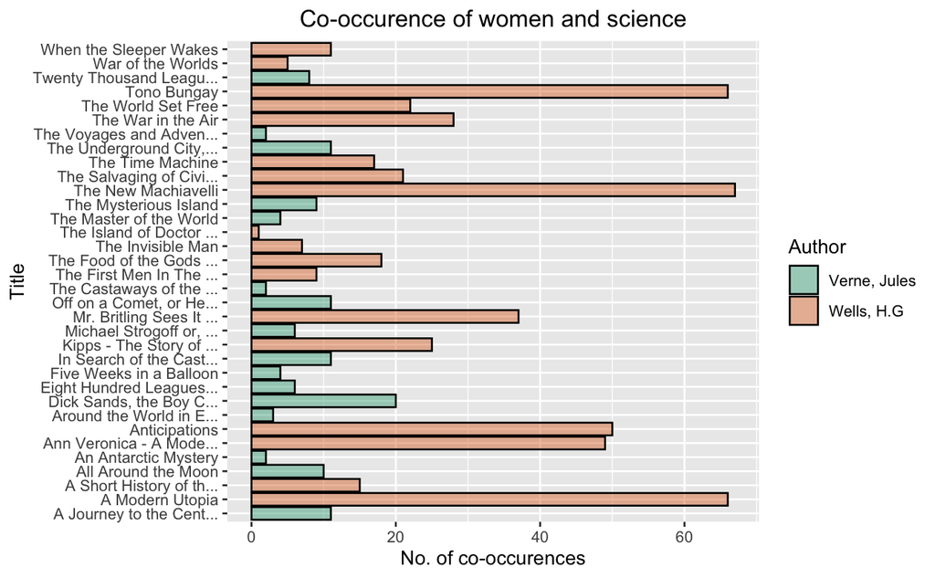

**Graph 2.1**

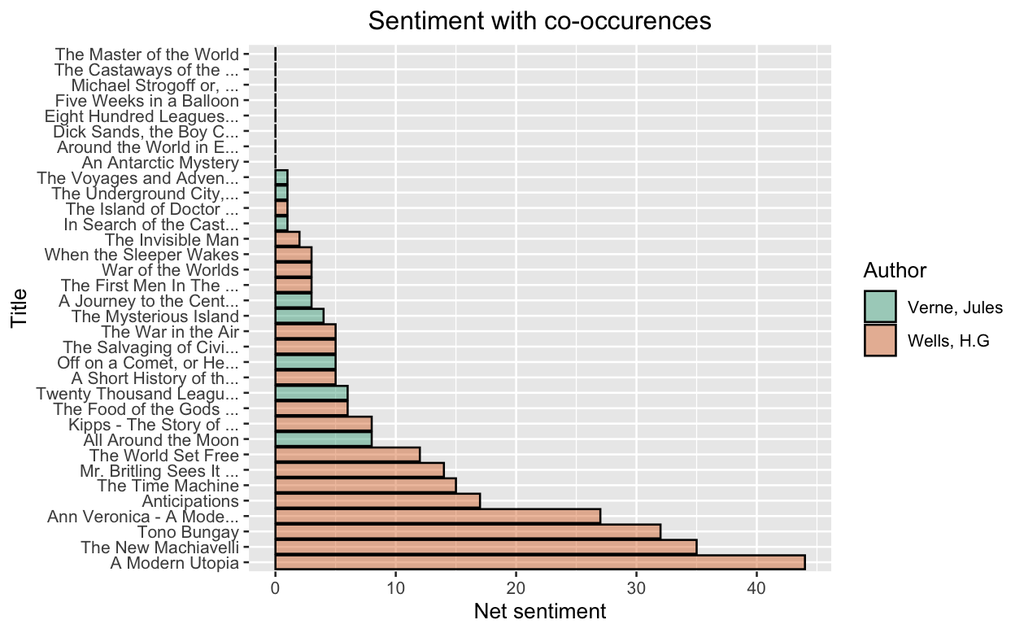

**Graph 2.2**

In a surprising turn of events, calculating the net sentiment with co-occurrences by title results in **Graph 2.2**. According to this, the net sentiment is always either neutral or positive, leading us to conclude that when women are in the same context as science, they’re not being written about negatively by either author. This is of great importance for our hypothesis since we expected to see the exact opposite. In relation to **Graph 2.1**, both concepts co-occur less frequently in Verne’s writing than that of Wells’s. Additionally, a good chunk of these occurrences in Verne’s novels result in strictly neutral sentiment. This distinction can be better represented in **Graph 2.3** which splits **Graph 2.2** by author.

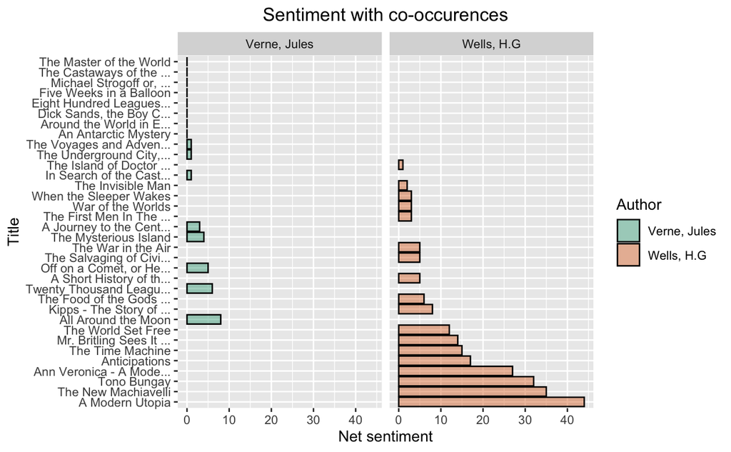

**Graph 2.3**

Here we can see that 50% of Verne’s texts have a net sentiment score of 0. So not only does he write less frequently about female characters in relation to science, but also reduces their involvement to negligible amounts. This could possibly mean that he sees the role of women as being distinct from contexts related to science. Essentially, these two categories are non-intersecting or minimally intersecting in his writing. Conversely, none of Wells’s texts has a net sentiment score of 0. Rather, Wells writes more frequently and positively in comparison to Verne, meaning that women in his novels occupy relevant positions in proximate science-related contexts. Also given the existence of Wells’s female-centric novels like *Ann Veronica*, his writing seems to suggest that women have the capacity to be protagonists as opposed to passive side characters. This concurs with the high frequency of co-occurring paragraphs in his novels, as well as the sentiment of his novels (as we saw in **Graph 1.2**).

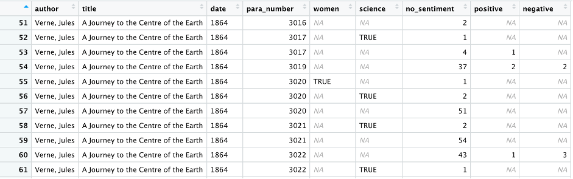

**Table 2.2**

Another line of analysis that could be fruitful here is looking at co-occurrences within a certain range of paragraphs. We came across this while examining the data table (**Table 2.2**). We saw that in some cases if a women cluster word appeared, a few paragraphs later, a science cluster word would appear and vice-versa. An example of this is in rows 52 and 55 where a women concept appears only 3 paragraphs after a science concept. There were also other examples where both concepts appeared within 1 or 2 paragraphs of each other. Hence, we realised that women and science do not necessarily have to appear within the same paragraph to be written in the context of one another. In fact, it would make sense for a character’s actions to take place in one paragraph and then the ripple effect of the same to appear a few paragraphs or even chapters later. However, defining an agreeable range of paragraphs to consider while doing this analysis is a bit challenging.

### Data Visualization 3 - Topic Collocates:

To build on this idea of ripple effects and indirect links between women and science, our third tool was topic collocates. Having already found explicit contexts where both concepts appear in proximity, our rationale for this tool was to uncover any distant contexts we had missed out on. By finding the most frequently occurring n-grams with both clusters, we would be able to create a compact environment of their usage and see if there was any overlap between the two. We used this tool with n = 3 because any lower than this was proving to be too vague and any greater than this was not resulting in phrases with high frequency. This struck a desirable balance between context and significance. We filtered the collocates for those phrases which had a frequency greater than 1 because this would suggest some repetition or pattern of importance.

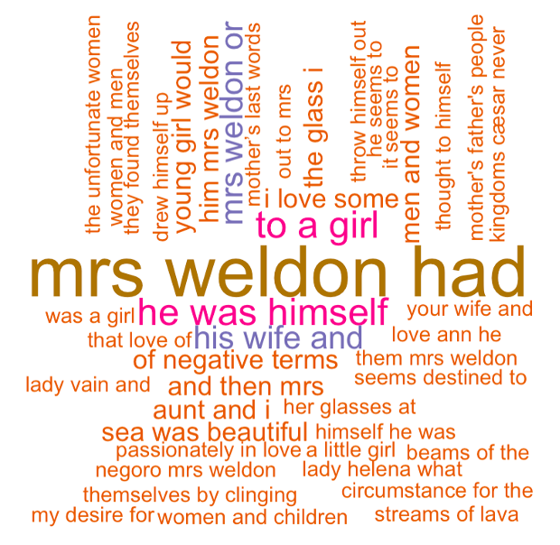

**Figure 3.1**

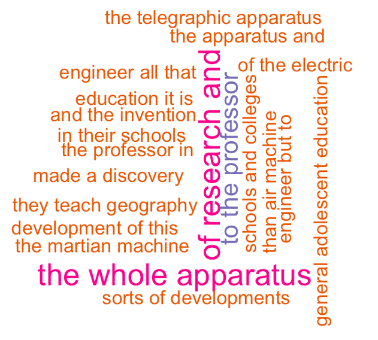

**Figure 3.2**

That being said, we decided to visualise the data from this tool using word clouds. We thought that if the data wasn’t making sense intuitively, perhaps mapping it visually would assist us in coming to a conclusion. The word cloud for women and science n-grams is **Figure 3.1** and **3.2** respectively. The phrase “mrs weldon” repetitively appears in **Figure 3.1**. Familial relationships like a mother, father, aunt and children are also common. As for **Figure 3.2**, schooling and education seem to be recurring ideas. The terms “apparatus” and “development” also keep popping up. At this point, if there was a common theme like education to both word clouds, that could have been another line of analysis. Unfortunately, there seem to be no matches between the collocates branches for either cluster. Using this visualisation in our scenario was somewhat unconventional because word clouds are usually used for single terms and not phrases. As a result of this, some of our phrases were left out by a spatial error that couldn’t fit everything within the same word cloud. This only added to our confusion regarding the topic collocates and so we had to return to manually examining the raw data table.

In the table for the women cluster n-grams, we found some valuable ideas that could represent further links like: “aerostatics ascensions madame”, “ first class engineer” and “for loading firearms”. Yet, all of these had a frequency of 1 and so were filtered out in our initial cleaning of the table. However, is repetition/reproducibility enough to suggest significance and vice versa? It is possible that the same phrase appears in another form with synonyms and so its cumulative frequency might be greater than 1. Even if the exact words are retained but the grammatical structure of the phrase is different it’s seen as a distinct entity altogether. For example, there are 8 variations of the phrase “for loading firearms” across the corpus so its actual frequency should not be 1. Due to this, we assert that while topic collocates can be incredibly helpful, in the case of our research, we found that it didn’t bring additional precision to our argument or findings.

### Conclusion

Over the course of this project, we were not able to conclusively prove our hypothesis. This was due to several reasons, the foremost being that we were unable to find sufficient evidence that indicated women being depicted as distractions. Of all the paragraphs that mention either our women cluster or science cluster, only 0.06% have mentions of both. So, the absence of both concepts being mentioned in the context of one another made it difficult to establish a direct causal link that women detract from scientific developments. This absence was made even clearer through our word clouds. We had hoped to demonstrate examples of women being associated with irrationality while science existed rationally in opposition to them. Through the data we have shown, it is clear that we were not able to locate substantiation for this, but we did find ourselves steered towards an alternative conclusion. By the end of our multiple levels of sentiment analysis and topic collocates, we found that one can conclusively say that when women and science cluster words co-occur in the same paragraph, they are written about positively or at least neutrally. This coincides with the results from our first visualisation where we concluded that women in general contexts had a larger positive than negative sentiment. This must mean that the negative sentiments surrounding women must come from a space other than science and technology. Further, between the two authors in our corpus, H.G. Wells writes far more frequently about women and science in the same proximate context whereas Jules Verne writes relatively infrequently about the same together. Even with regard to the emergent net sentiment of those co-occurring paragraphs, Wells writes more positively about the two clusters together, than Verne. Therefore, we deduce that not only does Wells prioritise women as significant characters in his novels in relation to science and technology, they are also written about in positive connotations whereas this is less true for Verne.

### Reflection

Text analysis with R is multiple levels above Voyant – both in flexibility and complexity. There is absolute freedom to experiment with packages, libraries and themes to broaden the scope of your analysis. This ability to tweak and customise helped us make our visualisations more readable, for e.g. sorting by a chosen variable, flipping the axes and modifying colour palettes. But with this freedom comes a lot of complexity. We found that the code is not very intuitive so there is always a time lag when it comes to playing around with tools. First, we need to understand the algorithm and only then we can tweak it to our benefit. In this sense, experimenting with Voyant is slightly quicker. Not understanding the code and editing it would lead to unreliable results and having to manually pore through raw data tables. From our limited experience with R, it seems as though it has fewer visualisation options as compared to Voyant. While Voyant boasts choices like TermsBerry, Loom and Mandala we are unsure whether R could reproduce these with ease. That being said, with R we were able to use tools that aren’t available on Voyant, namely sentiment analysis and finding co-occurrences of two concepts. These two were indispensable to our research and we can confidently say that we would not reach the same conclusion with Voyant. We think that to profit from the advantages of both text analysis methods, it is best to use them in conjunction with each other.

Sentiment analysis was a huge part of our research and we decided to go with the Bing lexicon over NRC or AFINN. Given that these lexicons are crowdsourced and heavily subjective, there is a limit to how accurate our results are. While our preference for Bing was justified, we wonder whether the results would vary immensely if we opted for AFINN. Similarly, running the same analysis with the NRC lexicon could be helpful in categorising broader sentiments if our hypothesis was edited to require this. Another takeaway from our research is the concept of ripple effects. Since we were looking at the actions of women in the context of science, we aimed to track and predict their effects across the plot. We tried to do this with co-occurrences but limited ourselves to matches between a paragraph. Instead, we could have also included a range of paragraphs between which our relevant results would lie but we decided against it because we could not arrive at an appropriate range without close reading. We felt as though drawing conclusions from an unsubstantiated range of paragraphs would lead to inaccurate results.

Given that our research was oriented towards the role played by women in the development (or as distractions in the process) of technology in science fiction novels, we could potentially have looked at word clusters for verbs associated with contribution and disturbance. This would have honed in on the specific actions of women in the context of science. However, for the length and scope of this research project, we weren’t able to create and match this with the other two clusters through n-grams. Another factor for not doing this stemmed from the fact that our total co-occurrences (in paragraphs) of science and women were only 0.06% of the total mentions. The addition of a third variable cluster would likely reduce this percentage of co-occurrences further, potentially making the result negligible. However, this did pique our interest and it seems like a process that could still yield valuable insights if tried. As mentioned in the course of our work, we were often confronted with the possibility of no findings. Topic collocates as a tool was one where this rang the truest because its results felt fairly misleading and didn’t aid us as much as we hoped they would. Regardless, we think this was a needed lesson for our navigation through digital humanities: **be prepared to find nothing**.